# Untitled

Loading packages

```r
library(tidyverse)
library(rstan)
library(rethinking)
```

### Notation and definitions

Statistics in the Bayesian framework makes inferences by fitting a probability model to a set of data. The process of doing this involves (1) setting up a full probability model, (2) conditioning on observed data to calculate a *posterior distribution* and (3) evaluating the fit of the model and the resulting posterior to the data.

We’re interested in the quantity $p(\theta|y)$, namely what is the probability of our parameters $\theta$ given that we’ve collected our data $y$. Let $y = \left(y_1, y_2, \ldots, y_n\right)$ be a vector of data and $\theta = \left(\theta_1, \theta_2, \ldots, \theta_m\right)$ be a vector of parameters. By Bayes’ theorem,
$$\begin{align*}
p(\theta|y) = \frac{p(y|\theta)p(\theta)}{p(y)}.
\end{align*}$$
$p(\theta)$ is the prior distribution for $\theta$ and is generally taken to be the prior information we have about parameters $\theta$ before obtaining any data, and $p(y|\theta)$ is the likelihood given by the probability model we specify for the data-generating process.

Let $\tilde{y}$ be new data obtained after observing the data $y$. The posterior predictive distribution of $\tilde{y}$, obtaining by conditioning on the posterior based on $y$ is
$$\begin{align}
p(\tilde{y}|y) = \int p(\tilde{y}|\theta) p(\theta | y) \, d\theta
(\#eq:prediction)
\end{align}$$
Derivation:
$$\begin{align*}
p(\tilde{y}|y) &= \int p\left(\tilde{y}, \theta |y\right) \, d\theta\\
&= \int p\left(\tilde{y} | \theta , y\right)\, p\left(\theta|y\right) \, d\theta\\
&= \int p(\tilde{y}|\theta) p(\theta | y) \, d\theta
\end{align*}$$
The first line is given by the law of total probability. The second is uses the fact that $P(A, B) = P(B|A)P(A)$. The third line follows from the assumption that $y$ and $\tilde{y}$ are conditionally independent given $\theta$.

### Assessing model fit

Now the question is how do we start to measure how ``good’’ a model is based on its fit to the data. By good, we mean some vague mixture of the model explaining the data well (i.e. avoiding underfitting) while not learning too much the data as to reduce its predictive power (i.e. avoiding overfitting). The ideal measure for this is an out-of-sample predictive performance for new data that hasn’t been observed yet. Let $f$ be the true data-generating model, $y$ be the observed data, and $\tilde{y}$ be future data from the same data-generating process. Then for a single new data point $\tilde{y}_i$, we are interested in
$$\begin{align*}
\log p_\text{post}(\tilde{y}_i)
\end{align*}$$
which is the log predictive density for a new data point $\tilde{y}_i$ induced by the posterior distribution $p_\text{post}(\theta)$. Using equation @ref(eq:prediction),
$$\begin{align*}
\log(\tilde{y} | y) &= \log p_\text{post}(\tilde{y}_i) \\
&= \log \int p(\tilde{y}|\theta) p(\theta | y) \, d\theta \\
&= \log \int p(\tilde{y}|\theta) p_\text{post}(\theta) \, d\theta
\end{align*}$$

We can’t stop here though because we don’t actually know what the future $\tilde{y}_i$ data are, so we define an expected out-of-sample log predictive density for a new data point (**elpd**),
$$\begin{align*}
\text{elpd} &= \text{expected log predictive density for a new data point} \\
&= E_f\left(\log p_\text{post}(\tilde{y}_i)\right) \\
&= \int f(\tilde{y}_i) \log p_\text{post}(\tilde{y}_i) \, d\tilde{y}
\end{align*}$$
We don’t know what the data distribution $f$ is, so our goal is to estimate the elpd by finding the in-sample predictive density and correcting it for overfitting.

We extend this definition to a whole data set by adding up the elpd for each data point to obtain the **elppd**,
$$\begin{align*}
\text{elppd} &= \text{expected log pointwise predictive density for a new dataset} \\
&= \sum_{i = 1}^{n} E_f \left(\log p_\text{post} (\tilde{y}_i) \right)
\end{align*}$$
Here, we are dividing up the data $y$ into a set of data points $y_i$. This can be kind of awkward for data that aren’t independent, e.g. time series data or spatial data.

Of course, we don’t have an unlimited source of new data $\tilde{y}_i$ to calculate a out-of-sample predictive density, so we’re stuck with calculating the in-sample predictive density and then correcting it to estimate the elppd. Given that we have a posterior distribution $p_\text{post}(\theta) = p(\theta|y)$, the predictive accuracy of the fitted model to data is given by
$$\begin{align*}
\text{lppd} &= \text{log pointwise predictive density} \\
&= \log \Pi_{i = 1}^{n} p_\text{post}(\tilde{y}_i) \\
&= \sum_{i = 1}^{n} \log\int p(y_i|\theta)p_\text{post}(\theta) \, d\theta
\end{align*}$$
And with some sort of MCMC samplter, we estimate that integral with simulations. So, let our posterior stimulations be $M$ draws from $p_\text{post}(\theta)$ labeled $\theta^s$, $s = 1, \ldots, M$. Then the computed lppd is
$$\begin{align*}
\text{computed lppd} &= \text{computed log pointwise predictive density} \\
&= \sum_{i = 1}^{n} \log\left(\frac{1}{S} \sum_{s = 1}^{M} p(y_i | \theta^s)\right)
\end{align*}$$

### Information criteria and cross-validation

The computed lppd is always too optimistic about out-of-sample predictive accuracy so we need to correct it to get an estimate of the elppd. This is normally done by substracting a correction for the number of parameters or the effective number of parameters in the model. Conceptually, the effect number of parameters is a reflection of how “flexible” the model is, and a “flexible” model is more prone to overfit the observed data and reduce its ability to predict future data.

The classic non-Bayesian way to do this correction is to simply count the number of parameters in the model. This approach, encapsulated in the Akaike information criterion (AIC), uses the maximum-likelihood estimate for $\theta$ to calculate the lppd and then subtracts the number of parameters $k$,
$$\begin{align*}
\hat{\text{elpd}}_\text{AIC} = \log p(y | \hat{\theta}_\text{MLE}) - k
\end{align*}$$
We obtain the classic formula for AIC by multiplying by -2, obtaining $AIC = -2\log p(y | \hat{\theta}_\text{MLE}) + 2k$. And note that the first term in the AIC formula is simple the deviance of the model for the MLE parameters (as defined in Mcelreath’s book). AIC is limited in two ways: 1. It uses the MLE estimate for $\theta$ rather than incorporating uncertainty about $\theta$. We would prefer to use the whole posterior distribution in calculating the lppd 2. It simply uses the number of parameters $k$, which assumes flat priors. Once we start using informative priors and hierarchical models, our models will tend not to overfit as much.

WAIC is the fully Bayesian approach where
$$\begin{align*}
\hat{\text{elppd}}_\text{WAIC} = \text{lppd} - p_\text{WAIC}
\end{align*}$$
The $p_\text{WAIC}$ is the effective number of parameters term and is given by
$$\begin{align*}
p_\text{WAIC} = \sum_{i = 1}^n \text{var}_\text{post} \left(\log p(y_i|\theta) \right)
\end{align*}$$
This equation calculates the variance in the log predictive density for each data point over the whole posterior and then sums them all up.

### CODEEEE

Let’s simulate a data for a simple linear regression and see how WAIC changes with different models

```r
# parameters for the data-generating model
beta <- 3      # slope
alpha <- 5     # intercept
std_dev <- 15  # noise

# parameters for unrelated data
what1 <- .2
what2 <- 1

x_data <- rep(1:50, each = 5)
y_data <- beta * x_data + alpha + rnorm(length(x_data), 0, std_dev)
z_data <- beta * sin(x_data/7000) + rnorm(length(x_data), 0, std_dev)
dat <- data.frame(x = x_data, y = y_data, z = z_data) # tibbles don't work with rethinking
```

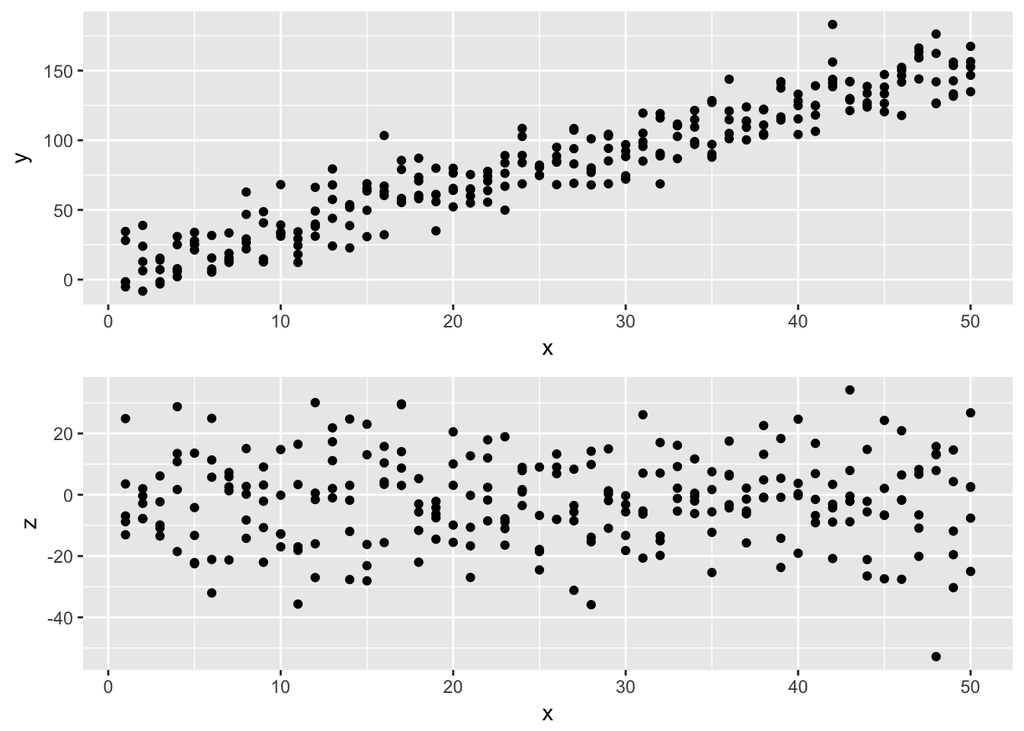

```r
egg::ggarrange(ggplot(dat) + geom_point(aes(x, y)),
               ggplot(dat) + geom_point(aes(x, z)))
```

Let’s run six different models: 1. m1: $y = b_1 x + a$ 2. m2: $y = b_1 x + b_2 x^2 + a$ 3. m3: $y = b2 x^2 + a$ 4. m4: $y = b_1 x + b_3 z + a$ 5. m5: $y = a$ 6. m6: $y = b_1 x + b_2 x ^ 2 + b_3 x ^ 3 + b_4 x^ 4 + a$

[output not shown]

[output cut: 655 more lines]

[output not shown]

Plotting the fits

```r
par(mfrow = c(3, 2))
mu <- link(m1)
```

```
#> [ 100 / 1000 ]
```

```r
[ 200 / 1000 ]
[ 300 / 1000 ]
[ 400 / 1000 ]
[ 500 / 1000 ]
[ 600 / 1000 ]
[ 700 / 1000 ]
[ 800 / 1000 ]
[ 900 / 1000 ]
[ 1000 / 1000 ]
mu_mean <- apply(mu, 2, mean)
mu_pi   <- apply(mu, 2, HPDI, prob = .89)
plot(y ~ x, data = dat, main = "m1")
lines(dat$x, mu_mean)
shade(mu_pi, dat$x)

mu <- link(m2)
```

```
#> [ 100 / 1000 ]
```

```r
[ 200 / 1000 ]
[ 300 / 1000 ]
[ 400 / 1000 ]
[ 500 / 1000 ]
[ 600 / 1000 ]
[ 700 / 1000 ]
[ 800 / 1000 ]
[ 900 / 1000 ]
[ 1000 / 1000 ]
mu_mean <- apply(mu, 2, mean)
mu_pi   <- apply(mu, 2, HPDI, prob = .89)
plot(y ~ x, data = dat, main = "m2")
lines(dat$x, mu_mean)
shade(mu_pi, dat$x)

mu <- link(m3)
```

```
#> [ 100 / 1000 ]
```

```r
[ 200 / 1000 ]
[ 300 / 1000 ]
[ 400 / 1000 ]
[ 500 / 1000 ]
[ 600 / 1000 ]
[ 700 / 1000 ]
[ 800 / 1000 ]
[ 900 / 1000 ]
[ 1000 / 1000 ]
mu_mean <- apply(mu, 2, mean)
mu_pi   <- apply(mu, 2, HPDI, prob = .89)
plot(y ~ x, data = dat, main = "m3")
lines(dat$x, mu_mean)
shade(mu_pi, dat$x)

mu <- link(m4)
```

```
#> [ 100 / 1000 ]
```

```r
[ 200 / 1000 ]
[ 300 / 1000 ]
[ 400 / 1000 ]
[ 500 / 1000 ]
[ 600 / 1000 ]
[ 700 / 1000 ]
[ 800 / 1000 ]
[ 900 / 1000 ]
[ 1000 / 1000 ]
mu_mean <- apply(mu, 2, mean)
mu_pi   <- apply(mu, 2, HPDI, prob = .89)
plot(y ~ x, data = dat, main = "m4")
lines(dat$x, mu_mean)
shade(mu_pi, dat$x)

mu <- link(m5)
```

```
#> [ 100 / 1000 ]
```

```r
[ 200 / 1000 ]
[ 300 / 1000 ]
[ 400 / 1000 ]
[ 500 / 1000 ]
[ 600 / 1000 ]
[ 700 / 1000 ]
[ 800 / 1000 ]
[ 900 / 1000 ]
[ 1000 / 1000 ]
mu_mean <- apply(mu, 2, mean)
mu_pi   <- apply(mu, 2, HPDI, prob = .89)
plot(y ~ x, data = dat, main = "m5")
lines(dat$x, mu_mean)
shade(mu_pi, dat$x)

mu <- link(m6)
```

```
#> [ 100 / 1000 ]
```

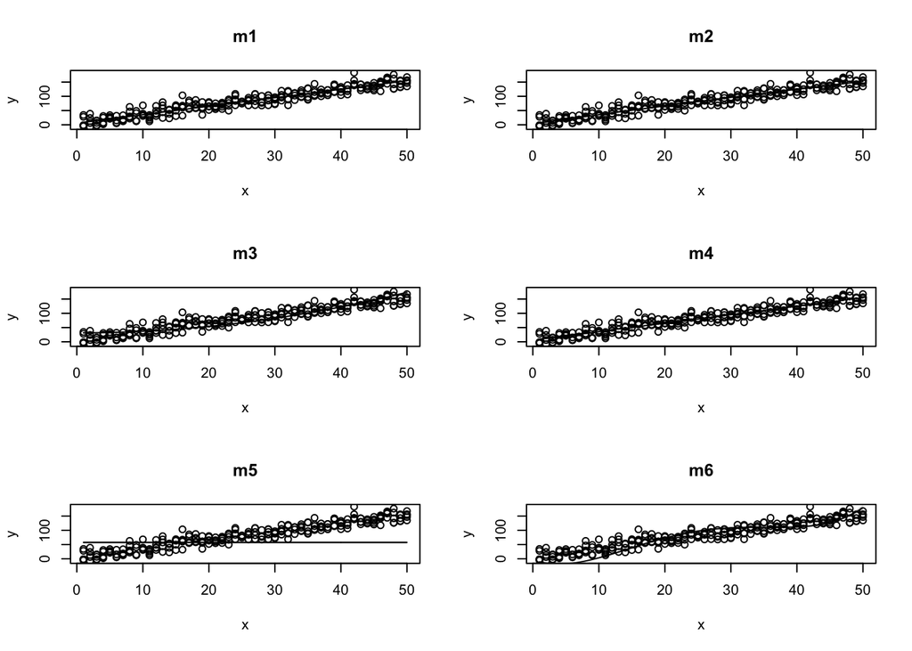

```r
[ 200 / 1000 ]
[ 300 / 1000 ]
[ 400 / 1000 ]
[ 500 / 1000 ]
[ 600 / 1000 ]
[ 700 / 1000 ]
[ 800 / 1000 ]
[ 900 / 1000 ]
[ 1000 / 1000 ]
mu_mean <- apply(mu, 2, mean)
mu_pi   <- apply(mu, 2, HPDI, prob = .89)
plot(y ~ x, data = dat, main = "m6")
lines(dat$x, mu_mean)
shade(mu_pi, dat$x)
```

```r
par(mfrow = c(1, 1))
```

```r
comp_ic <- compare(m1, m2, m3, m4, m5, m6)
df <- comp_ic@output %>% mutate(lppd = (WAIC - 2 * pWAIC) / -2)
comp_ic
```

```
#>      WAIC pWAIC dWAIC weight    SE   dSE
#> m1 2049.6   3.1   0.0   0.51 24.65    NA
#> m2 2050.7   4.0   1.1   0.29 24.71  2.34
#> m4 2051.5   4.3   1.8   0.20 24.81  1.34
#> m3 2174.2   3.0 124.5   0.00 21.27 17.56
#> m6 2307.4   3.2 257.7   0.00 21.58 21.49
#> m5 2680.4   1.3 630.8   0.00 17.90 28.33
```